# Assignment 9 Model Exploration and Interpretation

2023-03-22

I am adressing a data set on grad school admissions from the file *GradSchool_Admissions.csv*

The **packages** I used in R:

```r
library(tidyverse)
library(readr)
library(easystats)
library(patchwork)
library(GGally)
library(modelr)
```

**Initial Data Examination and Transformation**

creating a new data frame **df** from *GradSchool_Admissions.csv*

```r
df <- read_csv("./Assignment_9_Data/GradSchool_Admissions.csv")
```

examine the new data a bit

```r
glimpse(df)
```

```
## Rows: 400
## Columns: 4
## $ admit <dbl> 0, 1, 1, 1, 0, 1, 1, 0, 1, 0, 0, 0, 1, 0, 1, 0, 0, 0, 0, 1, 0, 1…
## $ gre   <dbl> 380, 660, 800, 640, 520, 760, 560, 400, 540, 700, 800, 440, 760,…
## $ gpa   <dbl> 3.61, 3.67, 4.00, 3.19, 2.93, 3.00, 2.98, 3.08, 3.39, 3.92, 4.00…
## $ rank  <dbl> 3, 3, 1, 4, 4, 2, 1, 2, 3, 2, 4, 1, 1, 2, 1, 3, 4, 3, 2, 1, 3, 2…
```

```r
summary(df)
```

```
##      admit             gre             gpa             rank
##  Min.   :0.0000   Min.   :220.0   Min.   :2.260   Min.   :1.000
##  1st Qu.:0.0000   1st Qu.:520.0   1st Qu.:3.130   1st Qu.:2.000
##  Median :0.0000   Median :580.0   Median :3.395   Median :2.000
##  Mean   :0.3175   Mean   :587.7   Mean   :3.390   Mean   :2.485
##  3rd Qu.:1.0000   3rd Qu.:660.0   3rd Qu.:3.670   3rd Qu.:3.000
##  Max.   :1.0000   Max.   :800.0   Max.   :4.000   Max.   :4.000
```

heres the data in table form

```r
df %>% kableExtra::kable() %>% kableExtra::kable_classic(lightable_options = 'hover') %>%
  kableExtra::scroll_box(width="500px", height = "200px")
```

| admit | gre | gpa | rank |
| --- | --- | --- | --- |
| 0 | 380 | 3.61 | 3 |
| 1 | 660 | 3.67 | 3 |
| 1 | 800 | 4.00 | 1 |
| 1 | 640 | 3.19 | 4 |
| 0 | 520 | 2.93 | 4 |
| 1 | 760 | 3.00 | 2 |
| 1 | 560 | 2.98 | 1 |
| 0 | 400 | 3.08 | 2 |
| 1 | 540 | 3.39 | 3 |
| 0 | 700 | 3.92 | 2 |
| 0 | 800 | 4.00 | 4 |
| 0 | 440 | 3.22 | 1 |
| 1 | 760 | 4.00 | 1 |
| 0 | 700 | 3.08 | 2 |
| 1 | 700 | 4.00 | 1 |
| 0 | 480 | 3.44 | 3 |
| 0 | 780 | 3.87 | 4 |
| 0 | 360 | 2.56 | 3 |
| 0 | 800 | 3.75 | 2 |
| 1 | 540 | 3.81 | 1 |
| 0 | 500 | 3.17 | 3 |
| 1 | 660 | 3.63 | 2 |
| 0 | 600 | 2.82 | 4 |
| 0 | 680 | 3.19 | 4 |
| 1 | 760 | 3.35 | 2 |
| 1 | 800 | 3.66 | 1 |
| 1 | 620 | 3.61 | 1 |
| 1 | 520 | 3.74 | 4 |
| 1 | 780 | 3.22 | 2 |
| 0 | 520 | 3.29 | 1 |

[output cut: 370 more lines]

Looks like the ‘admit’ column contains values 0 and 1, when this is logical data, I should change this into a TRUE~FALSE vector with 1= TRUE and 0 = FALSE for admittance to grad school

I’m also going to make rank a factor with levels 1-4 seeing as these rankings are discreet with only 4 possible options.

```r
df <- df %>% mutate(admit=as.logical(admit), rank=as.factor(rank))
```

That should be much better, let’s check, heres a glimpse and a table of the better data

```r
glimpse(df)
```

```
## Rows: 400
## Columns: 4
## $ admit <lgl> FALSE, TRUE, TRUE, TRUE, FALSE, TRUE, TRUE, FALSE, TRUE, FALSE, …
## $ gre   <dbl> 380, 660, 800, 640, 520, 760, 560, 400, 540, 700, 800, 440, 760,…
## $ gpa   <dbl> 3.61, 3.67, 4.00, 3.19, 2.93, 3.00, 2.98, 3.08, 3.39, 3.92, 4.00…
## $ rank  <fct> 3, 3, 1, 4, 4, 2, 1, 2, 3, 2, 4, 1, 1, 2, 1, 3, 4, 3, 2, 1, 3, 2…
```

```r
df %>% kableExtra::kable() %>% kableExtra::kable_classic(lightable_options = 'hover') %>%
  kableExtra::scroll_box(width="500px", height = "200px")
```

| admit | gre | gpa | rank |
| --- | --- | --- | --- |
| FALSE | 380 | 3.61 | 3 |
| TRUE | 660 | 3.67 | 3 |
| TRUE | 800 | 4.00 | 1 |
| TRUE | 640 | 3.19 | 4 |
| FALSE | 520 | 2.93 | 4 |
| TRUE | 760 | 3.00 | 2 |
| TRUE | 560 | 2.98 | 1 |
| FALSE | 400 | 3.08 | 2 |
| TRUE | 540 | 3.39 | 3 |
| FALSE | 700 | 3.92 | 2 |
| FALSE | 800 | 4.00 | 4 |
| FALSE | 440 | 3.22 | 1 |
| TRUE | 760 | 4.00 | 1 |
| FALSE | 700 | 3.08 | 2 |
| TRUE | 700 | 4.00 | 1 |
| FALSE | 480 | 3.44 | 3 |
| FALSE | 780 | 3.87 | 4 |
| FALSE | 360 | 2.56 | 3 |
| FALSE | 800 | 3.75 | 2 |
| TRUE | 540 | 3.81 | 1 |
| FALSE | 500 | 3.17 | 3 |
| TRUE | 660 | 3.63 | 2 |
| FALSE | 600 | 2.82 | 4 |
| FALSE | 680 | 3.19 | 4 |
| TRUE | 760 | 3.35 | 2 |
| TRUE | 800 | 3.66 | 1 |
| TRUE | 620 | 3.61 | 1 |
| TRUE | 520 | 3.74 | 4 |
| TRUE | 780 | 3.22 | 2 |
| FALSE | 520 | 3.29 | 1 |

[output cut: 370 more lines]

I want to predict admittance base on other variables in the data, let’s have a look at what these variables are

```r
df %>% select(-admit) %>% names()
```

```
## [1] "gre"  "gpa"  "rank"
```

gre represents an admissons test score

gpa is grade point average

rank is what rank the college is 1 being the ‘best’

**Variable Relationships**

Next lets see how the variables relate to one another

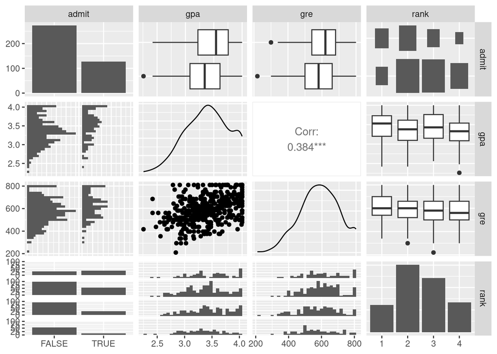

```r
df %>% select(admit, gpa, gre, rank) %>% ggpairs()
```

It looks like all 3 variables are going to have an impact on admittance, however it looks like some of the variables might be associated with one another, I will explore this more when modeling.

Let’s see how gre, gpa, and rank relate to admittance

first we’ll look at the relationship between gpa and admittance

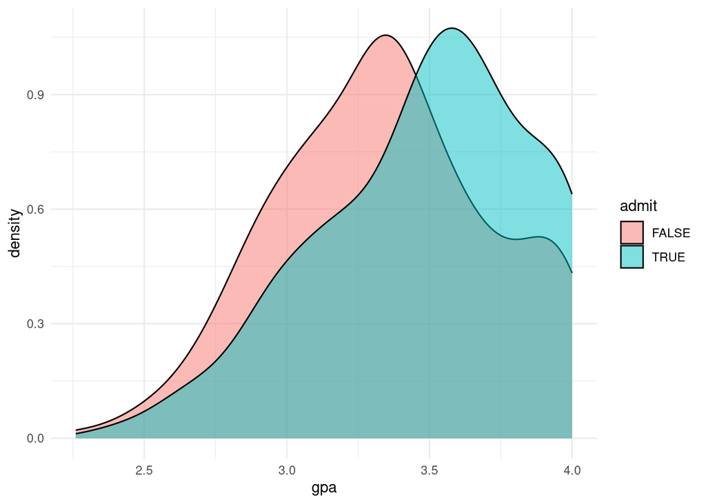

```r
df %>% ggplot(aes(x=gpa, fill=admit)) + geom_density(alpha=.5)+theme_minimal()
```

looks like the peak for getting admitted was at a 3.5 gpa and the peak for not getting admitted was below that.

it looks like above a 3.5 gpa the density of admittance was greater than non - admittance

next we’ll look at the relationship between gre score and admittance

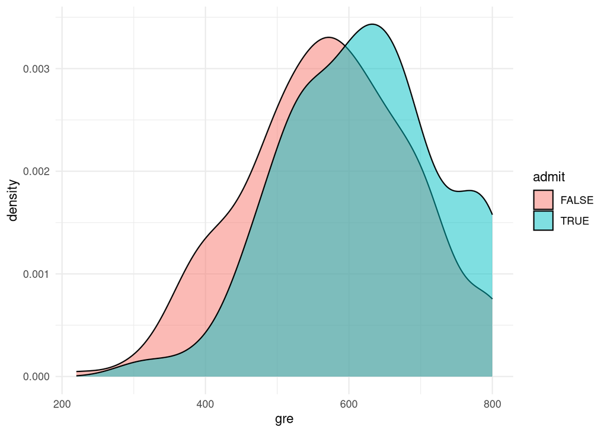

```r
df %>% ggplot(aes(x=gre, fill=admit)) + geom_density(alpha=.5)+theme_minimal()
```

the peak for being admitted is just above 600 while the peak of non admittance is below that.

then we’ll examine the relationship between rank and admittance

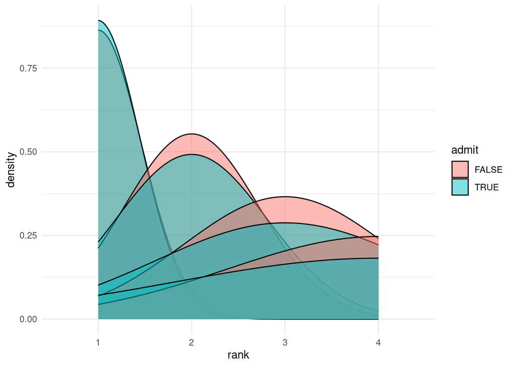

```r
df %>% mutate(rank=as.factor(rank)) %>% ggplot(aes(x=rank, fill=admit))+
  geom_density(alpha=.5)+theme_minimal()
```

this probably means a lot more people were nont admitted overall and expecially for each of these ranks below 1

it also might be valuable to explore relationships between the variables (gre, gpa, and rank) themselves

gre and rank

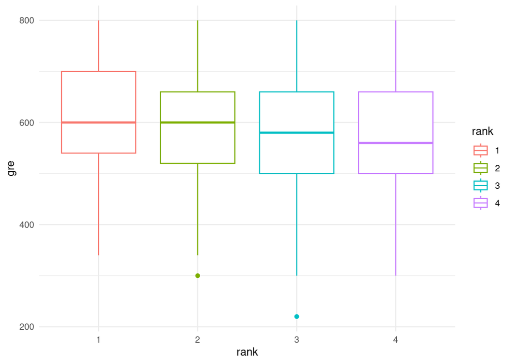

```r
df %>% ggplot(aes(x=rank, y=gre, group=rank, color=rank))+geom_boxplot()+theme_minimal()
```

rank doesn’t appear to impact gre score too much

gpa and rank

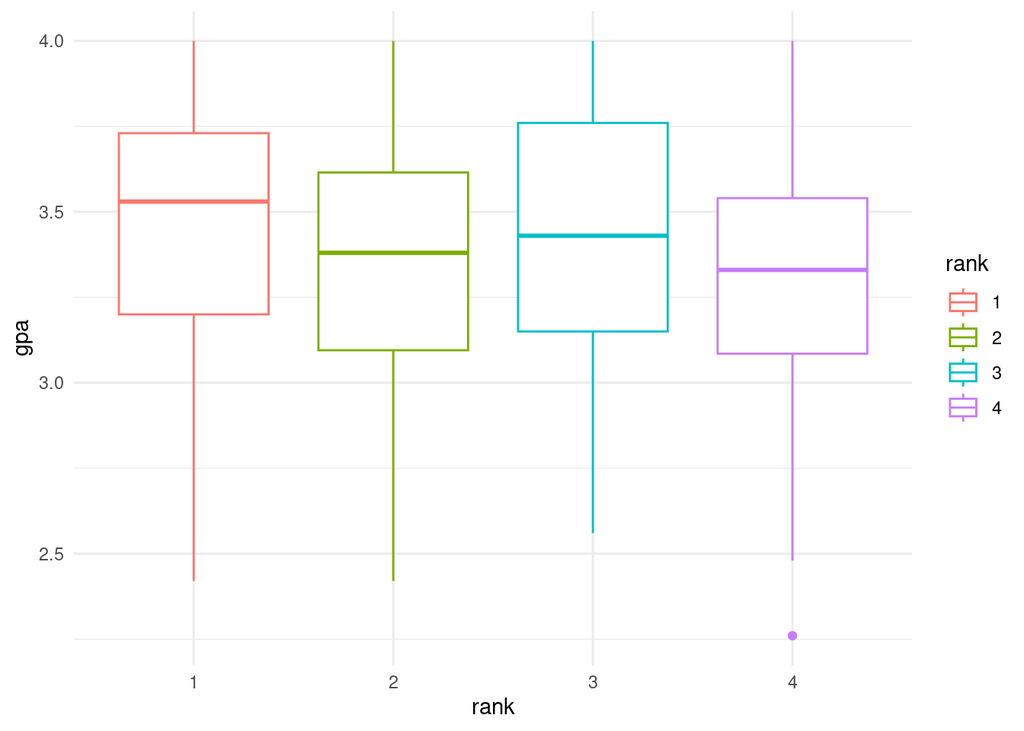

```r
df %>% ggplot(aes(x=rank, y=gpa, group=rank, color=rank))+geom_boxplot()+theme_minimal()
```

same story with gpa, rank doesn’t seem to be highly associated

gpa and gre

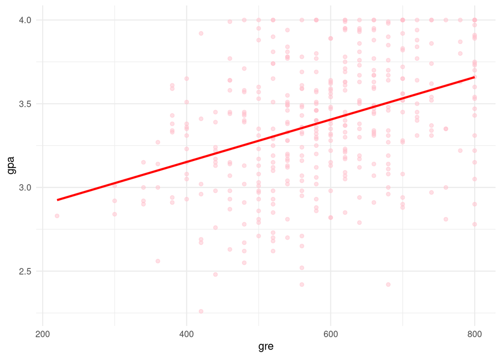

```r
df %>% ggplot(aes(x=gre, y=gpa))+geom_point(alpha=.5, color="pink")+geom_smooth(se=FALSE, method='glm', color="red")+theme_minimal()
```

as you can see here as gre score goes up so does gpa, however there is still a lot of discrepancy

**on to modeling**

I defined several models ranging in complexity to try to describe the relationship and predict an outcome (admit) based on predictors (gpa, gre, rank) and the relationships between them.

```r
mod <- glm(data=df, formula = admit~gre + gpa + rank, family = binomial)
mod2 <- glm(data=df, formula = admit~rank*gre*gpa, family=binomial)
```

mod2 wast the most complex it can get, I want to see if I can use step AIC from the MASS package to find a better equation to represent the relationship between all variables

heres what it will puke out:

```r
step <- MASS::stepAIC(mod2, trace=0)
step$formula
```

```
## admit ~ rank + gre + gpa + gre:gpa
```

plug that into a new model

```r
mod3 <- glm(data=df, formula= step$formula, family=binomial)
```

continue with modeling

```r
mod4 <- glm(data=df, formula = admit~gre*gpa + rank, family=binomial)
mod5 <- glm(data=df, formula=admit~rank, family=binomial)
mod6 <- glm(data=df, formula=admit~gpa*gre*rank+rank+gpa+gre, family=binomial)
mod7 <- glm(data=df, formula=admit~gpa+rank, family=binomial)
mod8 <- glm(data=df, formula = admit~gre+gpa*rank, family=binomial)
```

Now that all my models are made I want to find out which one is the best

```r
compare <- compare_performance(mod,mod2,mod3,mod4,mod5,mod6,mod7,mod8,rank=TRUE)
compare
```

```
## # Comparison of Model Performance Indices
##
## Name | Model | Tjur's R2 |  RMSE | Sigma | Log_loss | Score_log | Score_spherical |   PCP | AIC weights | AICc weights | BIC weights | Performance-Score
## --------------------------------------------------------------------------------------------------------------------------------------------------------
## mod3 |   glm |     0.108 | 0.439 | 1.077 |    0.570 |   -50.748 |           0.004 | 0.613 |       0.339 |        0.335 |       0.052 |            64.24%
## mod4 |   glm |     0.108 | 0.439 | 1.077 |    0.570 |   -50.748 |           0.004 | 0.613 |       0.339 |        0.335 |       0.052 |            64.24%
## mod  |   glm |     0.102 | 0.441 | 1.079 |    0.573 |   -50.755 |           0.004 | 0.611 |       0.234 |        0.239 |       0.266 |            57.24%
## mod7 |   glm |     0.092 | 0.443 | 1.083 |    0.579 |   -50.347 |           0.003 | 0.607 |       0.072 |        0.076 |       0.601 |            48.34%
## mod2 |   glm |     0.117 | 0.438 | 1.083 |    0.563 |   -51.599 |           0.005 | 0.617 |    6.18e-04 |     3.47e-04 |    1.51e-12 |            39.54%
## mod6 |   glm |     0.117 | 0.438 | 1.083 |    0.563 |   -51.599 |           0.005 | 0.617 |    6.18e-04 |     3.47e-04 |    1.51e-12 |            39.54%
## mod8 |   glm |     0.103 | 0.441 | 1.082 |    0.573 |   -50.954 |           0.003 | 0.611 |       0.014 |        0.013 |    4.07e-05 |            36.16%
## mod5 |   glm |     0.063 | 0.451 | 1.095 |    0.594 |   -49.265 |           0.010 | 0.594 |    4.63e-04 |     5.01e-04 |       0.028 |            30.48%
```

this gives me a score (%)

I can also compare the performance visually

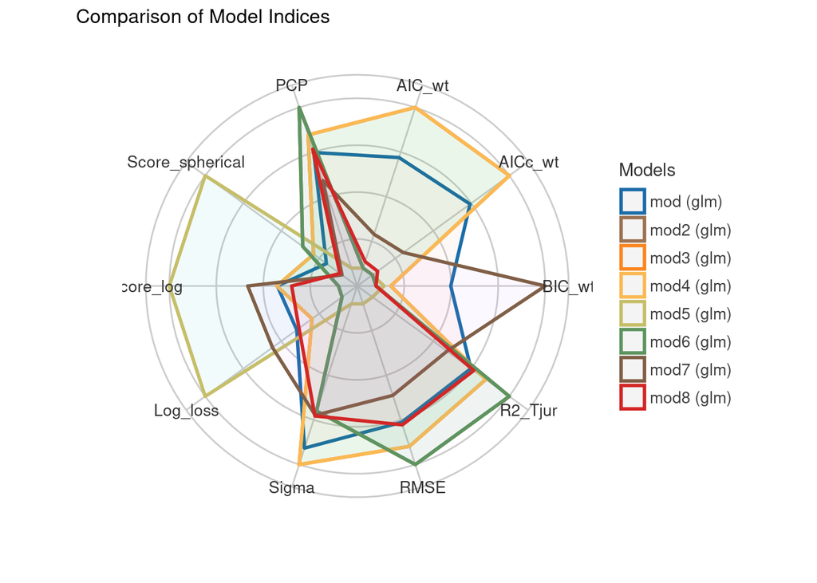

```r
compare_performance(mod,mod2,mod3,mod4,mod5,mod6,mod7,mod8) %>% plot()
```

based on these model 3 and 4 are tied for the best

mod4 is probably the simplest so I will choose that one

lets check the model real quick

```r
check_model(mod4)
```

```
## Variable `Component` is not in your data frame :/
```

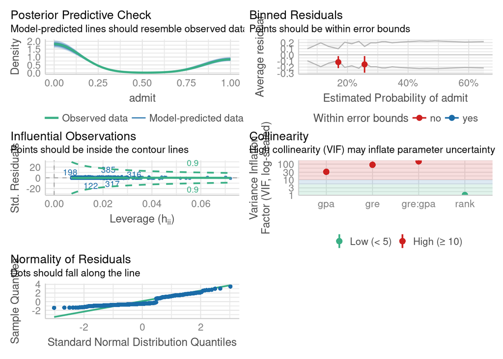

its not PERFECT but its pretty good.

to further test out this data set, I want to see how it will perform when it gets new information

to do this I wll randomy split the data into a training and testing set

first I will pick random samples to be the data that the model is tested on

```r
set.seed(162)
test<- sample(1:nrow(df),size=round(nrow(df)*.2))
test
```

```
##  [1] 289 111 184 168 374 251 347  76 117 259  40 286 110 196 278 386 356 333 185
## [20] 156 167 213 302  68 301   2 317  63  25  80  90 339 174 233  14 370 261 215
## [39]  31 105 271 337  61 247 116 283 245 151  69 108 128 277 226 395 180 143 222
## [58] 279 340 234 375 305 189  85  15 335  70  36 214 345 377 177 140 170  87 221
## [77] 224 223  21  48
```

then I will use this to subset the original data frame to the training and testing set

```r
testing <- df[test,]
trained <- df[-test,]
```

next I will use this to define a new model

```r
newmod4 <- glm(data=trained, formula=mod4$formula, family = binomial)
summary(newmod4)
```

```
##
## Call:
## glm(formula = mod4$formula, family = binomial, data = trained)
##
## Deviance Residuals:
##     Min       1Q   Median       3Q      Max
## -1.5010  -0.8445  -0.6267   1.1422   2.1923
##
## Coefficients:
##               Estimate Std. Error z value Pr(>|z|)
## (Intercept) -10.840840   6.753837  -1.605 0.108463
## gre           0.013753   0.011074   1.242 0.214274
## gpa           2.789373   1.983586   1.406 0.159657
## rank2        -0.698214   0.363512  -1.921 0.054764 .
## rank3        -1.474566   0.399395  -3.692 0.000223 ***
## rank4        -1.509507   0.471629  -3.201 0.001371 **
## gre:gpa      -0.003306   0.003211  -1.030 0.303111
## ---
## Signif. codes:  0 '***' 0.001 '**' 0.01 '*' 0.05 '.' 0.1 ' ' 1
##
## (Dispersion parameter for binomial family taken to be 1)
##
##     Null deviance: 395.90  on 319  degrees of freedom
## Residual deviance: 359.77  on 313  degrees of freedom
## AIC: 373.77
##
## Number of Fisher Scoring iterations: 4
```

```r
check_model(newmod4)
```

```
## Variable `Component` is not in your data frame :/
```

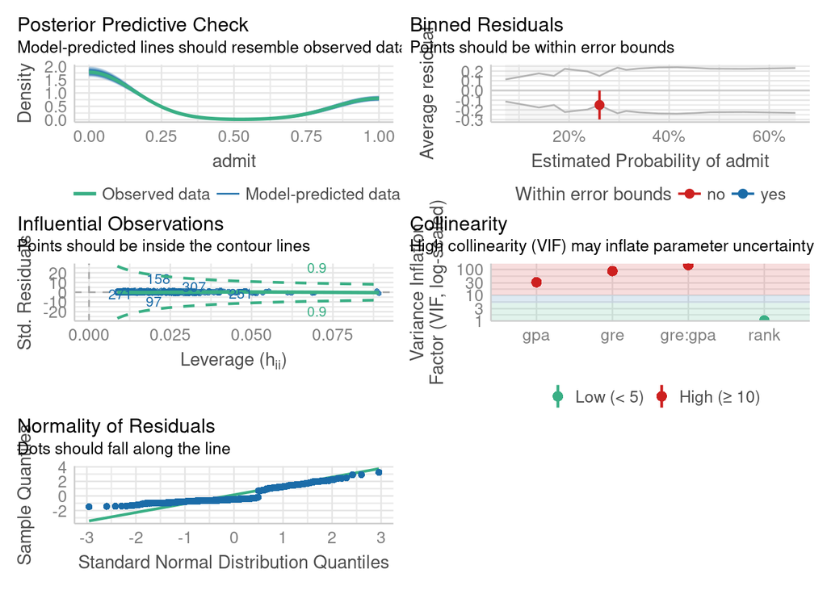

I will compare the performance of the new model to the old model

```r
compare_performance(newmod4,mod4, rank=TRUE)
```

```
## # Comparison of Model Performance Indices
##
## Name    | Model | Tjur's R2 |  RMSE | Sigma | Log_loss | Score_log | Score_spherical |   PCP | AIC weights | AICc weights | BIC weights | Performance-Score
## -----------------------------------------------------------------------------------------------------------------------------------------------------------
## newmod4 |   glm |     0.109 | 0.436 | 1.072 |    0.562 |   -38.238 |           0.006 | 0.619 |        1.00 |         1.00 |        1.00 |            90.00%
## mod4    |   glm |     0.108 | 0.439 | 1.077 |    0.570 |   -50.748 |           0.004 | 0.613 |    1.43e-21 |     1.48e-21 |    6.53e-22 |            10.00%
```

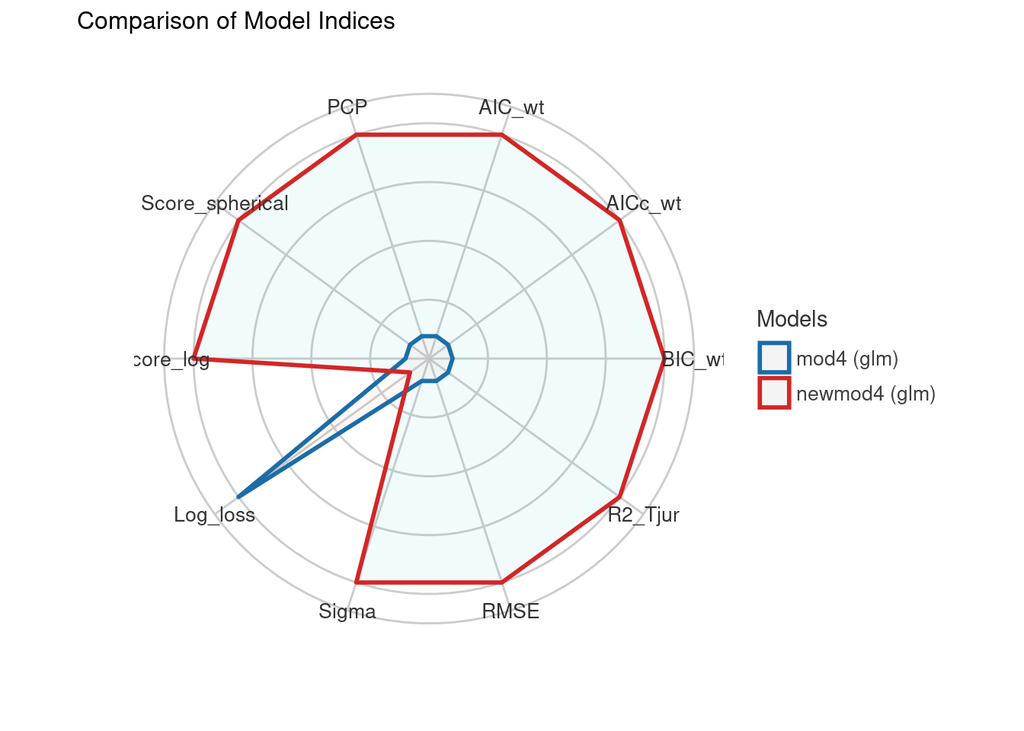

```r
compare_performance(newmod4,mod4) %>% plot()
```

newmod4 actually appears to be a little ‘better’

lets add predictions to the new model based on the testing data

```r
trained_pred <- add_predictions(testing, newmod4, type='response')
trained_pred
```

```
## # A tibble: 80 × 5
##    admit   gre   gpa rank   pred
##    <lgl> <dbl> <dbl> <fct> <dbl>
##  1 FALSE   800  3.15 4     0.290
##  2 FALSE   680  3.08 4     0.209
##  3 TRUE    540  3.84 2     0.436
##  4 FALSE   720  3.77 3     0.295
##  5 TRUE    620  3.37 1     0.544
##  6 FALSE   660  3.31 4     0.220
##  7 FALSE   600  3.35 2     0.357
##  8 FALSE   720  4    3     0.315
##  9 TRUE    440  3.45 2     0.292
## 10 FALSE   520  3.51 2     0.347
## # … with 70 more rows
```

not too bad, and avoiding overfitting too!

lets look at the rmse for both a good prediction of how well the model can predict the testing data

heres for the new model thats been trained (newmod4)

```r
add_residuals(data=testing,newmod4) %>% pluck("resid") %>% .^2 %>% mean(na.rm=TRUE) %>% sqrt()
```

```
## [1] 1.473404
```

and here’s for our original model using all data (mod4)

```r
add_residuals(data=testing,mod4) %>% pluck("resid") %>% .^2 %>% mean(na.rm=TRUE) %>% sqrt()
```

```
## [1] 1.442699
```

the old model has a lower rmse, but not by much.

The thing is mod4 has seen this data before, so its naturally going to be better at predicting the data its already seen.

However, newmod4 has a very similar rmse to newmod4 so it’s actually a stronger model because it can predict data it hasn’t seen before almost as well as the model that has seen this data can.

So, I am going to choose newmod4 to avoid overfitting and because it is a better predictor overall.

however, I am still going to show what the predicitons would look like with the old (untrained) model

here is how the untrained model predicts from the entire dataset

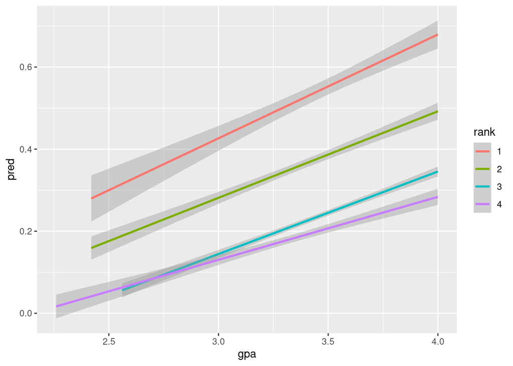

```r
dfwhole <- df %>% add_predictions(model=mod4, type='response')
fig1 <- dfwhole %>% ggplot(aes(x=gpa, y=pred, color=rank))+geom_smooth(method='glm')
fig1
```

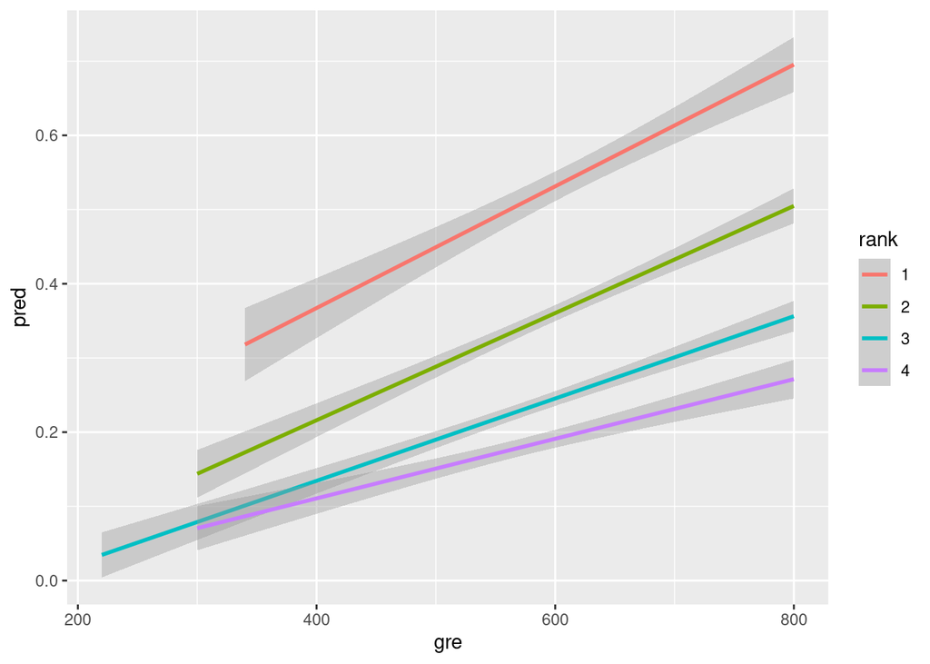

```r
fig2 <- dfwhole %>% ggplot(aes(x=gre, y=pred, color=rank))+geom_smooth(method='glm')
fig2
```

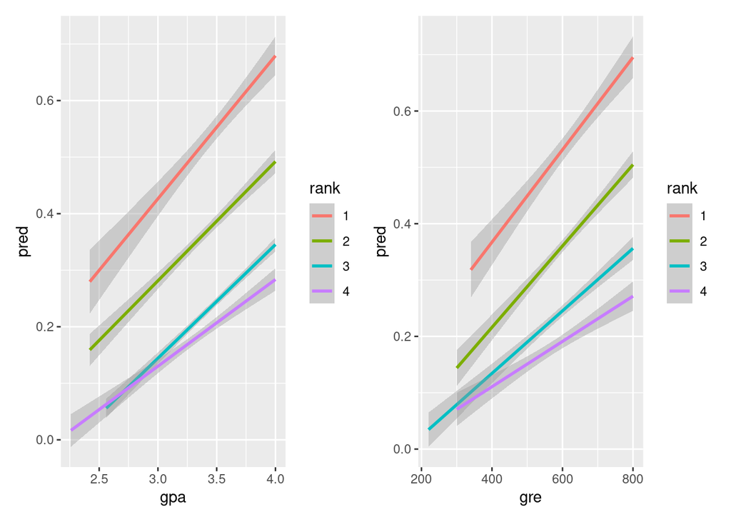

```r
fig1+fig2
```

and here is how the untrained model (mod4) predicts the testing data

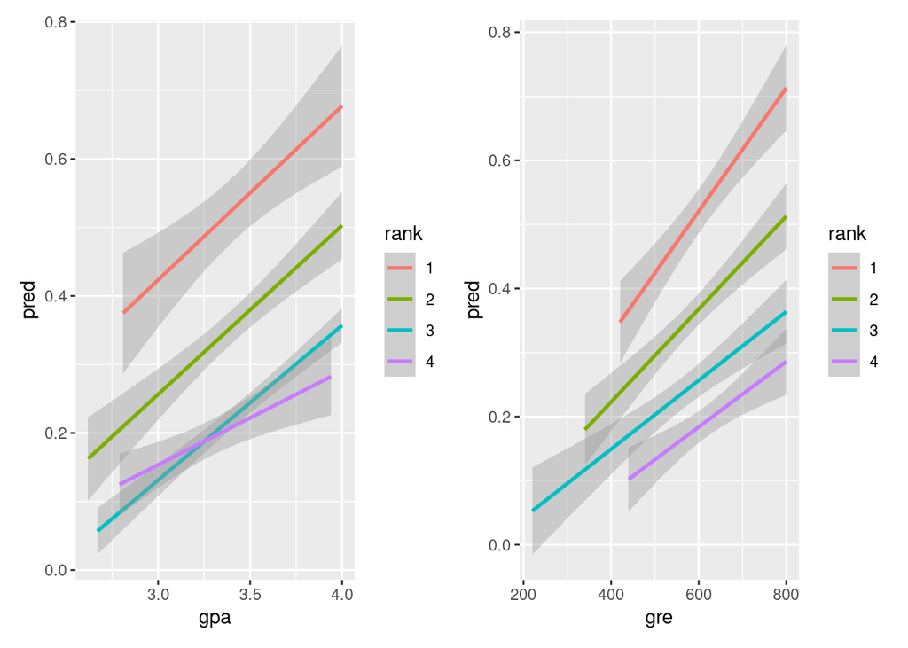

```r
df_og_test <- testing %>% add_predictions(model=mod4, type='response')
fig1.1 <-df_og_test %>% ggplot(aes(x=gpa, y=pred, color=rank))+geom_smooth(method='glm')
fig1.2 <- df_og_test %>% ggplot(aes(x=gre, y=pred, color=rank))+geom_smooth(method='glm')
fig1.1+fig1.2
```

here is how the trained model (newmod4) predicts the testing data

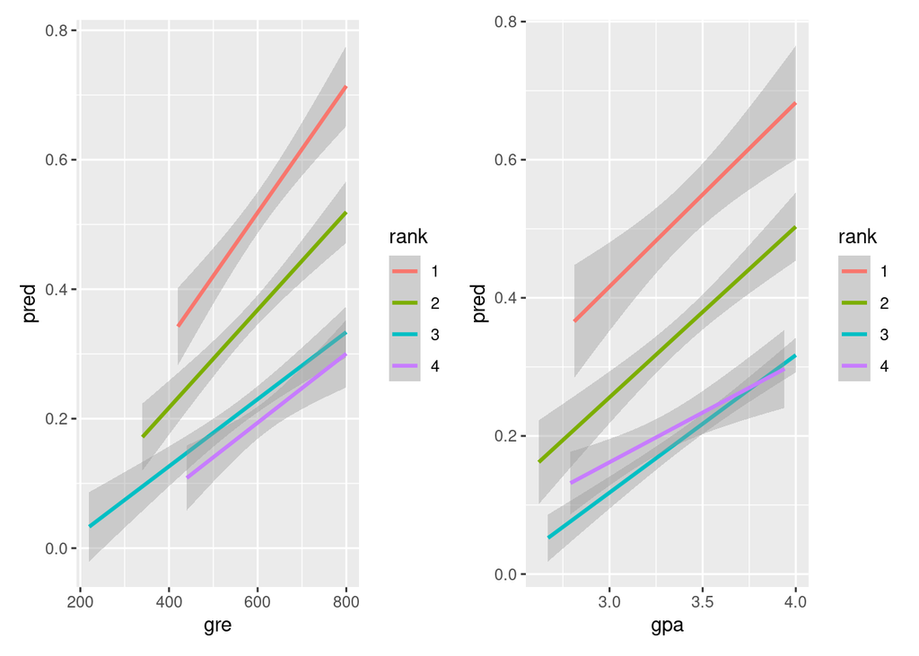

```r
fig3 <- trained_pred %>% ggplot(aes(x=gre, y=pred, color=rank))+geom_smooth(method='glm')
fig4 <- trained_pred %>% ggplot(aes(x=gpa, y=pred, color=rank))+geom_smooth(method='glm')
fig3+fig4
```

and here is how the trained model predicts the entire data set (trained+testing)

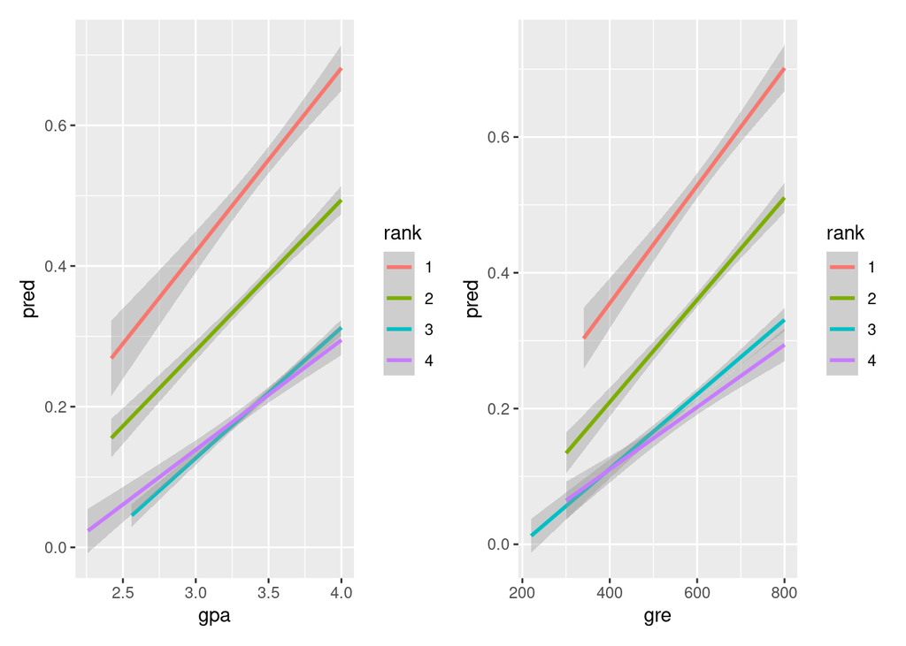

```r
df_trained <- df %>% add_predictions(model=newmod4, type='response')
fig5 <- df_trained %>% ggplot(aes(x=gpa, y=pred, color=rank))+geom_smooth(method='glm')
fig6 <-  df_trained %>% ggplot(aes(x=gre, y=pred, color=rank))+geom_smooth(method='glm')
fig5+fig6
```